# Statistical Rethinking Problems: Chapter 2

Simon Thornewill von Essen

2024-03-17

## 2E1

Which of the expressions below correspond to the statement: *the probability of rain on Monday*

$$P(\textrm{rain}) \\
P(\textrm{rain}|\textrm{Monday}) \\
P(\textrm{Monday}|\textrm{rain}) \\
\frac{P(\textrm{rain, Monday})}{P(\textrm{Monday})}$$

My answer is $P(\textrm{rain}|\textrm{Monday})$ because if something happen on Monday then we are conditioning on it. The first one is the probability that it rains without conditioning on anything, while the next is the probability it is Monday given that it rains.

The last one looks like a posterior distribution of some kind, but I don’t think it’s what we’re looking for.

## 2E2

Which of the following statements corresponds to the expression $P(\textrm{Monday}|\textrm{rain})$

1. The probability of rain on Monday
2. The probability of rain, given that it is Monday
3. The probability that it is Monday, given that it is raining
4. The probability that it is Monday and that it is raining

The answer is 3, because it is the probability that it is Monday given that it is raining. It cannot be 1 or 2 because it’s not the probability that it is raining to start with. It’s also not a joint probability as in 4, which would be $P(\textrm{rain}, \textrm{Monday})$.

## 2E3

Skip…

## 2E4

The Bayesian statistician Bruno de Finetti began his 1973 book on probability theory with the declaration “PROBABILITY DOES NOT EXIST.” The capitals appeared in the original, so I imagine de Finetti wanted us to shout this statement. What he meant is that probability is a device for describing uncertainty from the perspective of an observer with limited knowledge; it has no objective reality. Discuss the globe tossing example from the chapter, in light of this statement. What does it mean to say “the probability of water is 0.7”?

In order for something to be uncertain we simply don’t have access to what the true value for something is so by saying that the probability of water takes a certain value we quantify that uncertainty using a parameter value. However, we don’t know if this parameter is true either and so we can try to encode that uncertainty further in more complex ways.

## 2M1

Recall the globe tossing model from the chapter. Compute and plot the grid approximate posterior dist for each of the following sets of observations. In each case, assume a uniform prior for p.

1. W, W, W
2. W, W, W, L
3. L, W, W, L, W, W, W

```r
data = c(1, 1, 1)

grid_prior = seq(0, 1-0.001, 0.001)
prior = rep(1, 1000)

grid.df = data.frame(params=grid_prior,
                     prior=prior)

grid.df["posterior_WWW"] = dbinom(sum(data), length(data), grid_prior)
grid.df["posterior_WWW"] = grid.df["posterior_WWW"]/sum(grid.df["posterior_WWW"])

head(grid.df)
```

```
##   params prior posterior_WWW
## 1  0.000     1  0.000000e+00
## 2  0.001     1  4.008012e-12
## 3  0.002     1  3.206410e-11
## 4  0.003     1  1.082163e-10
## 5  0.004     1  2.565128e-10
## 6  0.005     1  5.010015e-10
```

We can now plot the posterior.

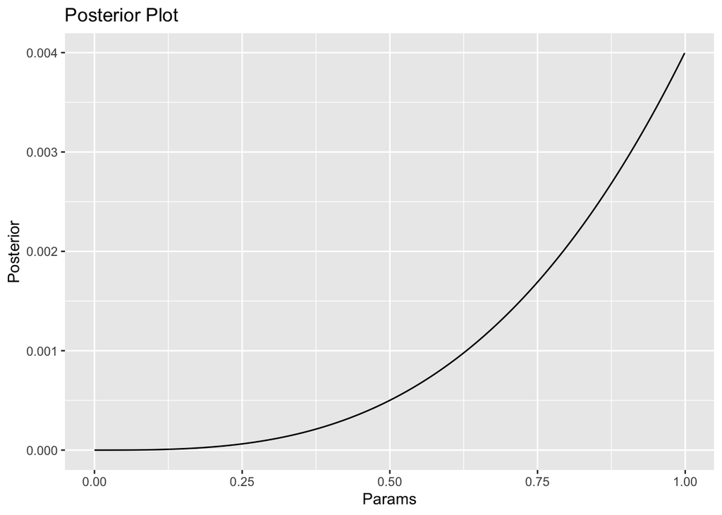

```r
ggplot(grid.df, aes(x = params, y = posterior_WWW)) +
  geom_line() +
  labs(x = "Params", y = "Posterior") +
  ggtitle("Posterior Plot")
```

Now we can do the same for if we were to draw an L, we can use the same posterior before as our prior but I calculated it from scratch because it was easy enough.

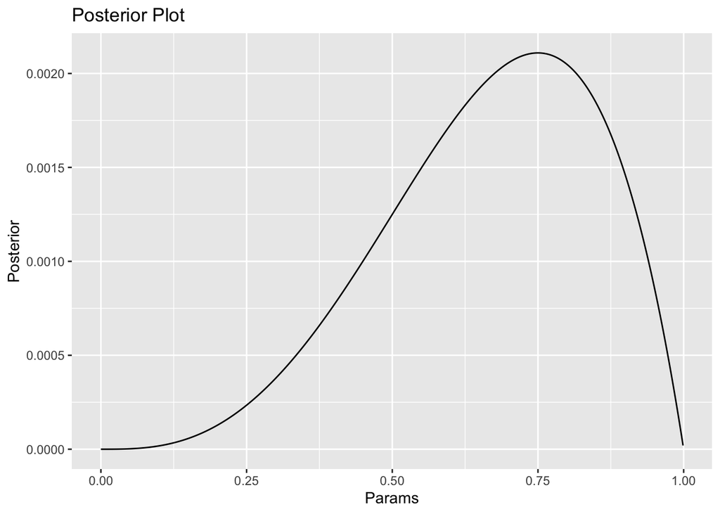

```r
grid.df["posterior_WWWL"] = dbinom(3, 4, grid_prior)
grid.df["posterior_WWWL"] = grid.df["posterior_WWWL"] /
  sum(grid.df["posterior_WWWL"])

ggplot(grid.df, aes(x = params, y = posterior_WWWL)) +
  geom_line() +
  labs(x = "Params", y = "Posterior") +
  ggtitle("Posterior Plot")
```

So now for the final one we have 5 positives out of 7 trials…

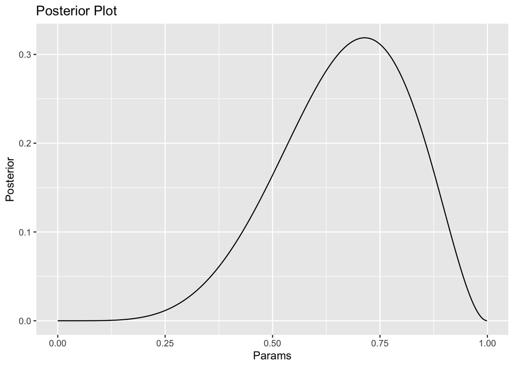

```r
grid.df["posterior_WWWLWWL"] = dbinom(5, 7, grid_prior)
grid.df["posterior_WWWLWWL"] = grid.df["posterior_WWWLWWL"] /
  sum(grid.df["posterior_WWWL"])

ggplot(grid.df, aes(x = params, y = posterior_WWWLWWL)) +
  geom_line() +
  labs(x = "Params", y = "Posterior") +
  ggtitle("Posterior Plot")
```

```r
head(grid.df)
```

```
##   params prior posterior_WWW posterior_WWWL posterior_WWWLWWL
## 1  0.000     1  0.000000e+00   0.000000e+00      0.000000e+00
## 2  0.001     1  4.008012e-12   1.998003e-11      2.095802e-14
## 3  0.002     1  3.206410e-11   1.596803e-10      6.693147e-13
## 4  0.003     1  1.082163e-10   5.383809e-10      5.072428e-12
## 5  0.004     1  2.565128e-10   1.274882e-09      2.133231e-11
## 6  0.005     1  5.010015e-10   2.487504e-09      6.497039e-11
```

## 2M2

Now assume a prior for p that is equal to zero when p < 0.5 and is a positive constant when p ≥ 0.5. Again compute and plot the grid approximate posterior distribution for each of the sets of observations in the problem just above

```r
grid.df.new = grid.df
grid.df.new["prior"] = append(rep(0, 500), rep(1, 500))

grid.df.new["posterior_WWW"] = grid.df.new["prior"]*grid.df["posterior_WWW"]
grid.df.new["posterior_WWW"] = grid.df.new["posterior_WWW"]/
  sum(grid.df.new["posterior_WWW"])

grid.df.new["posterior_WWWL"] = grid.df.new["prior"]*grid.df["posterior_WWWL"]
grid.df.new["posterior_WWWL"] = grid.df.new["posterior_WWWL"]/
  sum(grid.df.new["posterior_WWWL"])

grid.df.new["posterior_WWWLWWL"] = grid.df.new["prior"]*grid.df["posterior_WWWLWWL"]
grid.df.new["posterior_WWWLWWL"] = grid.df.new["posterior_WWWLWWL"]/
  sum(grid.df.new["posterior_WWWLWWL"])

head(grid.df.new)
```

```
##   params prior posterior_WWW posterior_WWWL posterior_WWWLWWL
## 1  0.000     0             0              0                 0
## 2  0.001     0             0              0                 0
## 3  0.002     0             0              0                 0
## 4  0.003     0             0              0                 0
## 5  0.004     0             0              0                 0
## 6  0.005     0             0              0                 0
```

Now we can comvine the columns and plot

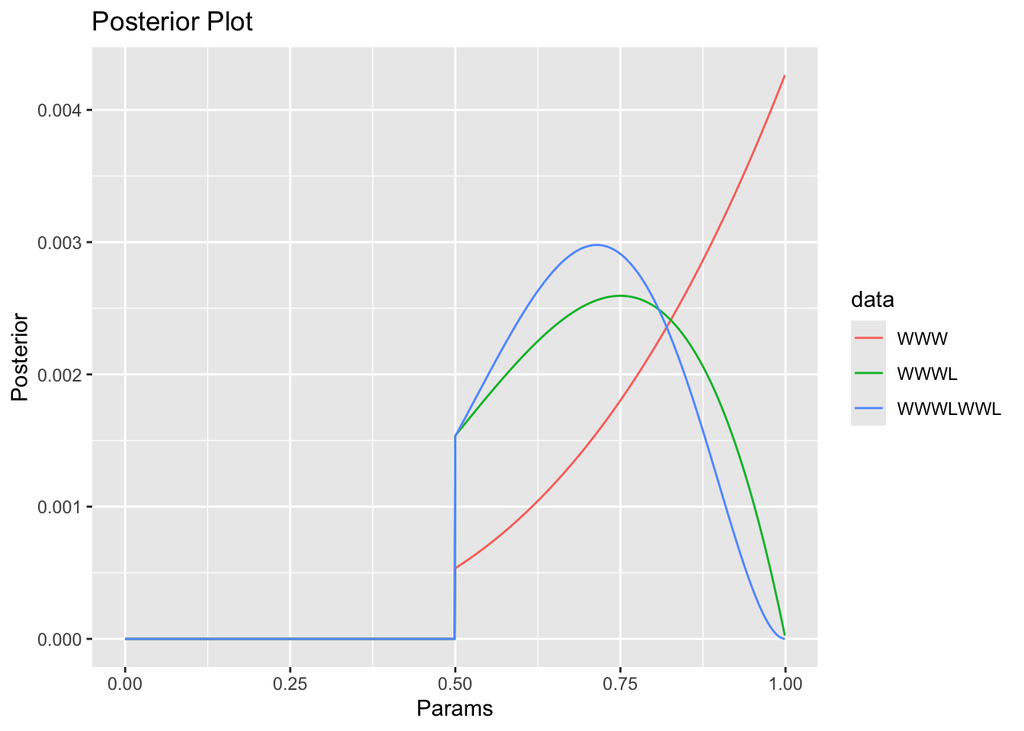

```r
grid.df.new.pivot = pivot_longer(grid.df.new,
                            cols = starts_with("posterior"),
                            names_to = "data",
                            values_to = "posterior") %>%
  mutate(data = sub("^posterior_", "", data))

ggplot(grid.df.new.pivot, aes(x = params, y = posterior, color=data)) +
  geom_line() +
  labs(x = "Params", y = "Posterior") +
  ggtitle("Posterior Plot")
```

## 2M3

Suppose there are two globes, one for Earth and one for Mars. The Earth globe is 70% covered in water. The Mars globe is 100% land. Further suppose that one of these globes—you don’t know which— was tossed in the air and produced a “land” observation. Assume that each globe was equally likely to be tossed. Show that the posterior probability that the globe was the Earth, conditional on seeing “land” ($P(\textrm{Earth}|\textrm{land})$), is 0.23.

```r
df.planets = data.frame(
  planet = c("Earth", "Mars"),
  prior = rep(0.5, 2),
  p_land = c(0.3, 1)
) %>%
  mutate(likelihood=dbinom(1, 1, p_land),
         posterior=likelihood*prior/sum(likelihood*prior))

df.planets
```

```
##   planet prior p_land likelihood posterior
## 1  Earth   0.5    0.3        0.3 0.2307692
## 2   Mars   0.5    1.0        1.0 0.7692308
```

We can see from the table that the posterior distribution that we have earth given that we saw land once (and the probabilities given) is 23%.

## 2M4

Suppose you have a deck with only three cards. Each card has two sides, and each side is either black or white. The cards are as follows:

1. One card has two black sides.
2. The second card has one black and one white side.
3. The third card has two white sides.

Now suppose all three cards are placed in a bag and shuffled. Someone reaches into the bag and pulls out a card and places it flat on a table. A black side is shown facing up, but you don’t know the color of the side facing down.

Show that the probability that the other side is also black is 2/3.

Hint: Use the counting method (Section 2 of the chapter) to approach this problem. This means counting up the ways that each card could produce the observed data (a black side facing up on the table.

```r
df.cards = data.frame(
  card_side_1_is_black=c(1, 1, 0),
  card_side_2_is_black=c(1, 0, 0),
  prior=rep(1/3, 3)
) %>%
  mutate(ways=card_side_1_is_black + card_side_2_is_black,
         posterior=ways*prior/sum(ways*prior))

df.cards
```

```
##   card_side_1_is_black card_side_2_is_black     prior ways posterior
## 1                    1                    1 0.3333333    2 0.6666667
## 2                    1                    0 0.3333333    1 0.3333333
## 3                    0                    0 0.3333333    0 0.0000000
```

We can see that the probability that we chose the double sided black card is 2/3 or or ~66%.

## 2M5

Now suppose there are four cards: B/B, B/W, W/W, and another B/B. Again suppose a card is drawn from the bag and a black side appears face up. Again calculate the probability that the other side is black.

```r
df.cards = data.frame(
  card_side_1_is_black=c(1, 1, 0),
  card_side_2_is_black=c(1, 0, 0),
  prior=c(2/4, 1/4, 1/4)
) %>%
  mutate(ways=card_side_1_is_black + card_side_2_is_black,
         posterior=ways*prior/sum(ways*prior))

df.cards
```

```
##   card_side_1_is_black card_side_2_is_black prior ways posterior
## 1                    1                    1  0.50    2       0.8
## 2                    1                    0  0.25    1       0.2
## 3                    0                    0  0.25    0       0.0
```

this should be the same as below…

```r
df.cards = data.frame(
  card_side_1_is_black=c(1, 1, 0, 1),
  card_side_2_is_black=c(1, 0, 0, 1),
  prior=c(1/4, 1/4, 1/4, 1/4)
) %>%
  mutate(ways=card_side_1_is_black + card_side_2_is_black,
         posterior=ways*prior/sum(ways*prior))

df.cards %>%
  filter((card_side_1_is_black==1) & (card_side_2_is_black==1)) %>%
  summarise(posterior_prob=sum(posterior))
```

```
##   posterior_prob
## 1            0.8
```

Indeed, we can see that the two methods are equivalent.

## 2M6

Imagine that black ink is heavy, and so cards with black sides are heavier than cards with white sides. As a result, it’s less likely that a card with black sides is pulled from the bag.

So again assume there are three cards: B/B, B/W, and W/W.

After experimenting a number of times, you conclude that for every way to pull the B/B card from the bag, there are 2 ways to pull the B/W card and 3 ways to  
pull the W/W card. Again suppose that a card is pulled and a black side appears face up. Show that the probability the other side is black is now 0.5. Use the counting method, as before.

```r
df.cards = data.frame(
  card_side_1_is_black=c(1, 1, 0),
  card_side_2_is_black=c(1, 0, 0),
  prior=c(1/6, 2/6, 3/6)
) %>%
  mutate(ways=card_side_1_is_black + card_side_2_is_black,
         posterior=ways*prior/sum(ways*prior))

df.cards
```

```
##   card_side_1_is_black card_side_2_is_black     prior ways posterior
## 1                    1                    1 0.1666667    2       0.5
## 2                    1                    0 0.3333333    1       0.5
## 3                    0                    0 0.5000000    0       0.0
```

## 2m7

Assume again the original card problem, with a single card showing a black side face up.

Before looking at the other side, we draw another card from the bag and lay it face up on the table. The face that is shown on the new card is white. Show that the probability that the first card, the one showing a black side, has black on its other side is now 0.75. Use the counting method, if you can.

Hint: Treat this like the sequence of globe tosses, counting all the ways to see each observation, for each possible first card.

It was difficult to represent this in code so the best way will be as follows

- black-black: 2 ways
  - white-black: 1 way
  - white-white: 2 ways
- black-white: 1 way
  - black-black: Not possible, 0
  - white-white: 2 way
- white-white: Not possible, 0

You then find the total number of ways we could have seen the data

```r
bb = 2
wb_bb = 1
ww_bb = 2
wb = 1
bb_wb = 0
ww_wb = 2

p_bb = bb * (wb_bb + ww_bb)

p_wb = wb * (ww_wb)

p_bb / (p_bb + p_wb)
```

```
## [1] 0.75
```

So, I think my problem was that I was trying to add column together…

```r
cards <- c("Black-Black", "Black-White", "White-White")
combinations <- expand.grid(Card_Type1 = cards,
                            Card_Type2 = cards) %>%
  filter(Card_Type1 != Card_Type2) %>%
  arrange(Card_Type1, Card_Type2) %>%
  mutate(Ways_Card1=c(2, 2, 1, 1, 0, 0),
         Ways_Card2=c(1, 2, 0, 2, 0, 1),
         prod=Ways_Card1*Ways_Card2,
         post=prod/sum(prod))

combinations %>%
  filter(Card_Type1=="Black-Black") %>%
  summarise(post_agg=sum(post))
```

```
##   post_agg
## 1     0.75
```

## 2h1

Suppose there are two species of panda bear. Both are equally common in the wild and live in the same places. They look exactly alike and eat the same food, and there is yet no genetic assay capable of telling them apart. They differ however in their family sizes.

- Species A gives birth to twins 10% of the time, otherwise birthing a single infant.
- Species B births twins 20% of the time, otherwise birthing singleton infants.

Assume these numbers are known with certainty, from many years of field research.

Now suppose you are managing a captive panda breeding program. You have a new female panda of unknown species, and she has just given birth to twins. What is the probability that her next birth will be twins.

I suppose that what we’d want to do is calculate the probability of the species

```r
df.pandas = data.frame(
  panda_type=c("A", "B"),
  prior=c(0.5, 0.5),
  likelihood=c(0.1, 0.2)
) %>%
  mutate(post=prior*likelihood/sum(prior*likelihood),
         next_post=c(0.1, 0.2),
         p_next_post=post*next_post)

df.pandas
```

```
##   panda_type prior likelihood      post next_post p_next_post
## 1          A   0.5        0.1 0.3333333       0.1  0.03333333
## 2          B   0.5        0.2 0.6666667       0.2  0.13333333
```

We know that we have one set of twins, so it’s just a matter of finding the likelihood of the next set of twins depending on the type

```r
sum(df.pandas["p_next_post"])
```

```
## [1] 0.1666667
```

## 2h2

Recall all the facts from the problem above. Now compute the probability that the panda we have is from species A, assuming we have observed only the first birth and that it was twins.

We already know from the table above that it’s 1/3.

## 2H3

Continuing on from the previous problem, suppose the same panda mother has a second birth and that it is not twins, but a singleton infant. Compute the posterior probability that this panda is species A.

```r
df.pandas = data.frame(
  panda_type=c("A", "B"),
  prior=c(1/3, 2/3),
  likelihood=c(1-0.1, 1-0.2)
) %>%
  mutate(post=prior*likelihood/sum(prior*likelihood))

df.pandas
```

```
##   panda_type     prior likelihood post
## 1          A 0.3333333        0.9 0.36
## 2          B 0.6666667        0.8 0.64
```

Re-tweaking the priors and the likelihood gives us the right answer.

## 2h4

A common boast of Bayesian statisticians is that Bayesian inference makes it easy to use all of the data, even if the data are of different types.

So suppose now that a veterinarian comes along who has a new genetic test that she claims can identify the species of our mother panda. But the test, like all tests, is imperfect. This is the information you have about the test:

- The probability it correctly identifies a species A panda is 0.8.
- The probability it correctly identifies a species B panda is 0.65.

The vet administers the test to your panda and tells you that the test is positive for species A.

First, ignore your previous information from the births and compute the posterior probability that your panda is species A. Then redo your calculation, now using the birth data as well.

```r
df.pandas = data.frame(
  panda_type=c("A", "B"),
  prior=c(1/2, 1/2),
  likelihood=c(0.8, 1-0.65)
) %>%
  mutate(post=prior*likelihood/sum(prior*likelihood))

df.pandas
```

```
##   panda_type prior likelihood      post
## 1          A   0.5       0.80 0.6956522
## 2          B   0.5       0.35 0.3043478
```

```r
df.pandas = data.frame(
  panda_type=c("A", "B"),
  prior=c(1/2, 1/2),
  likelihood=c(0.8, 1-0.65)
) %>%
  mutate(post_test=prior*likelihood/sum(prior*likelihood),
         like_twins=c(0.1, 0.2),
         post_test_twins=post_test*like_twins/sum(post_test*like_twins),
         like_single=1-like_twins,
         post_test_twins_single=post_test_twins*like_single/
           sum(post_test_twins*like_single)
         )

df.pandas
```

```
##   panda_type prior likelihood post_test like_twins post_test_twins like_single
## 1          A   0.5       0.80 0.6956522        0.1       0.5333333         0.9
## 2          B   0.5       0.35 0.3043478        0.2       0.4666667         0.8
##   post_test_twins_single
## 1                 0.5625
## 2                 0.4375
```